# Ashley Baker – Hedonic Spatial Regression

February 13th, 2019 |

| # **Spatial Hedonic Regression* |
| --- |

# Preparing Explanatory Variables

Variables that will be included in the model are identified as those which may have significant, yet sometimes indirect, impacts on the value of single family homes with Portland, OR. The intention of including these specific variables was to expand on the more obvious influential economic factors associated with home prices (ie, income) to include the comfort and safety of travel to amenities.

These variables are: * *Value* - dependent variable * *Crime* - represented as both the distance to the nearest report crime from the property, and the density of crimes reported within the CBG containing the property. * *Elevation* - represented as standard deviation of elevation, which indicates the variability of the terrain, and ultimately affects walkability * *Grocery Stores* - a necessary amenity, it could be expected that walkability to a grocery store would affect liveability * *Median Household Income* - represented by CBG, this indicates the median income of homeowners and renters within the surrounding area of the properties. * *Price/ ft2* - Value alone doesn’t necessarily tell the whole story, as the amount of space in addition to finishes and home quality, could directly affect this number * *Dangerous Roads* - Roads with high concentrations of accidents could impact the resident’s perception of safety during travel, both by car or while walking to amenities * *Owner Occupation* - It is possible that the value of a property could be associated with whether or not it is owner occupied * *Urban Heat Island* - This variable could impact both the walkability to amenities during hot summer months, but also the overall comfort of a particular area, thus having the potential to impact home values * *Green Space* - Derived from the most recent NLCD dataset for Portland, this green space density data is included as it implies potential protection from precipitation and heat for those traveling by foot. The additional aesthetics and privacy gleaned from trees and vegetation could also impact home values

Question: Which of the above variables exhibit a significant spatial correlation with home values in Portland, Oregon?

Question 2: What is the distribution of these observed relationship over the study area?

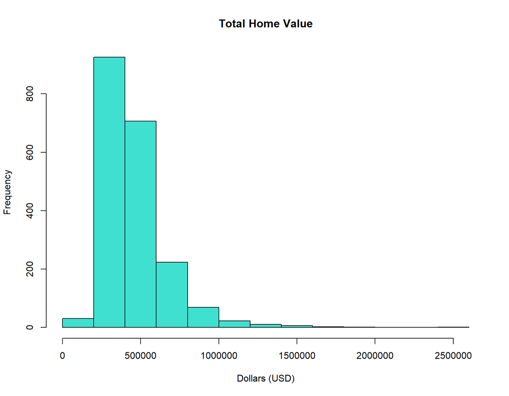

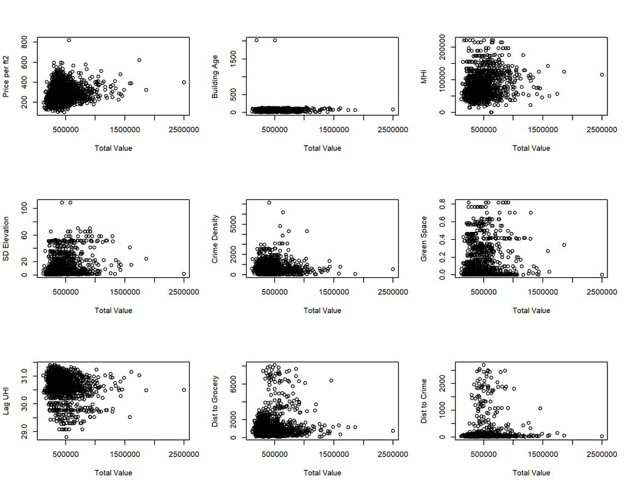

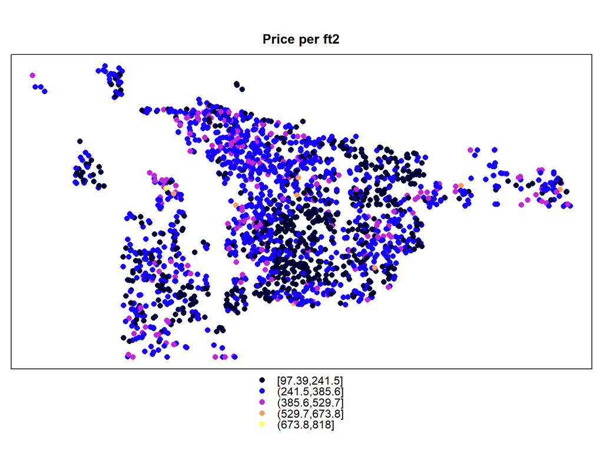

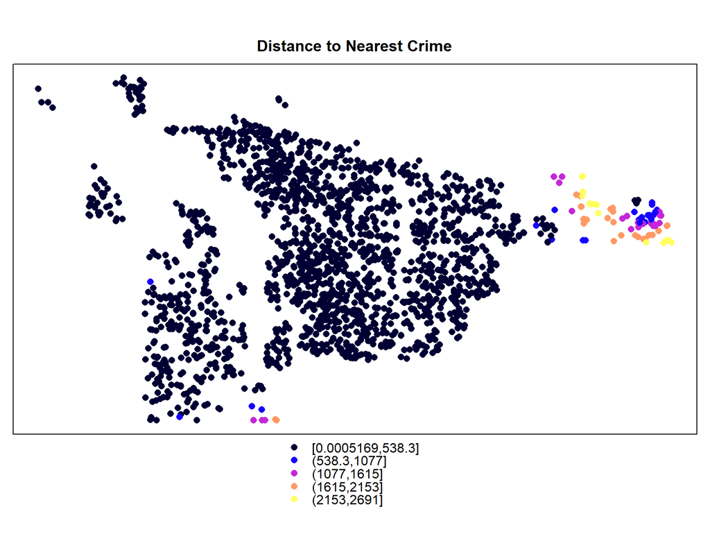

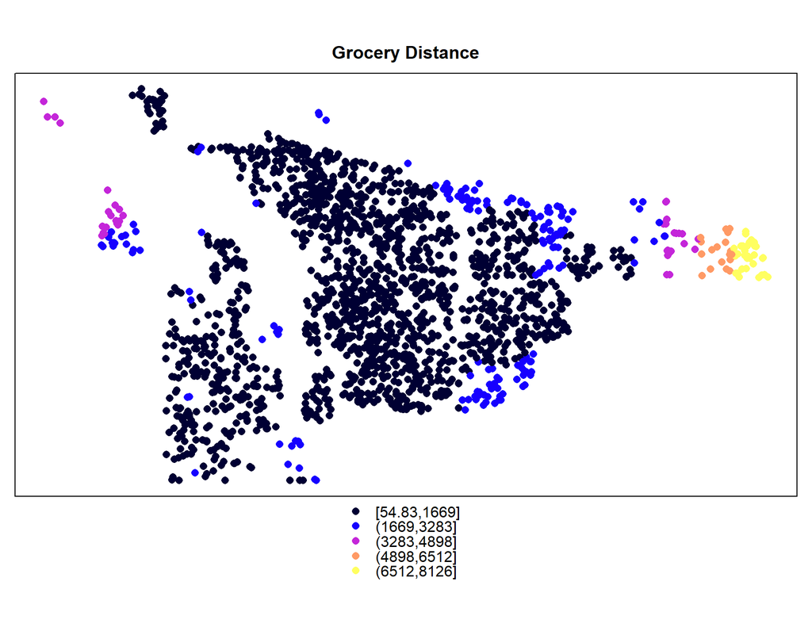

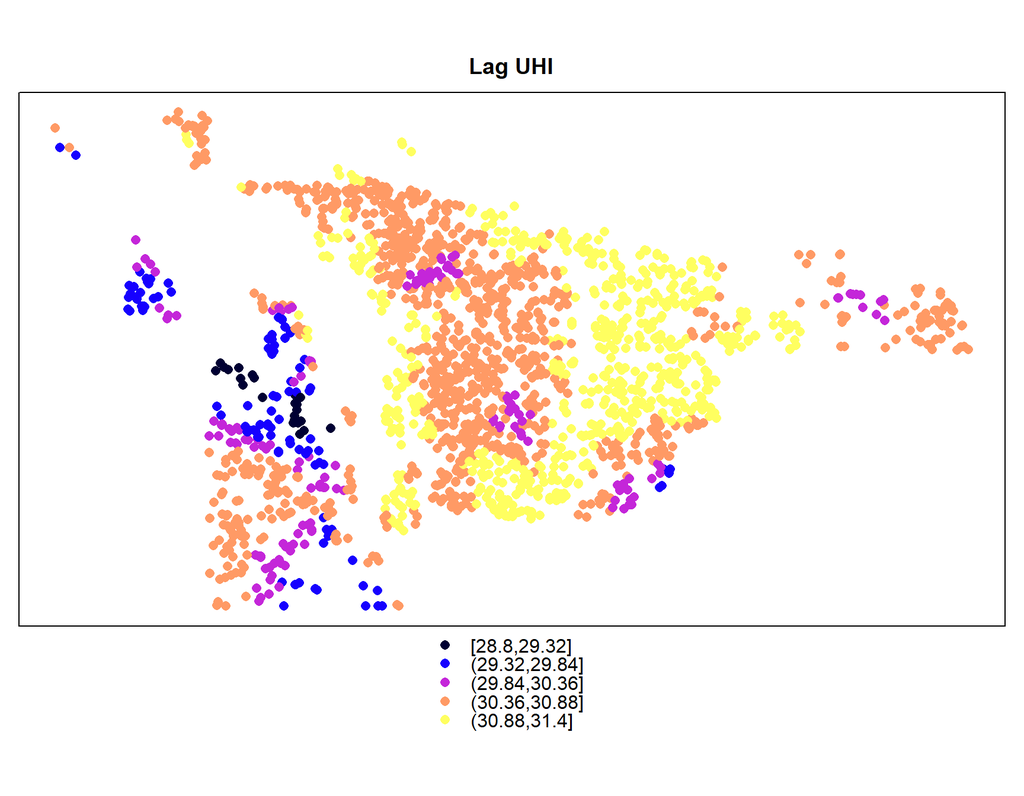

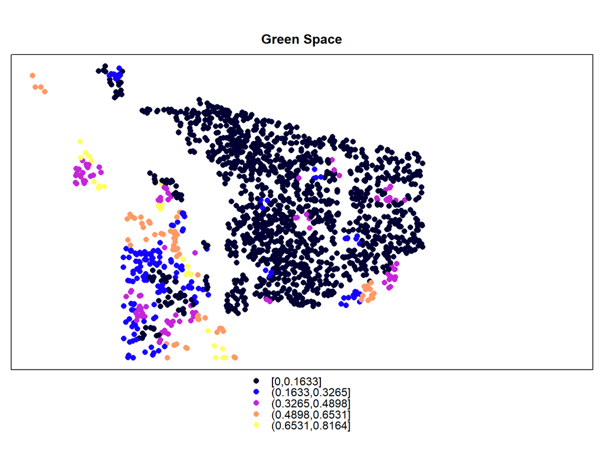

```r
#Begin processing variables for regression
#Create a dummy variable out of hedonic dataset- owner occupied
price$ownerocc <- ifelse(price$OWNERADDR==price$SITEADDR, 0, 1)

#explanatory variable:price per sqft
price$price_ft2 <- ifelse(price$TOTALVAL == 0, NA, price$TOTALVAL)/ ifelse(price$BLDGSQFT== 0, NA, price$BLDGSQFT)

#explanatory variable: building age
price$age <- as.numeric(2019-price$YEARBUILT)

#explanatory variable: median household income
cbg <- tidycensus::get_acs(
  geography = 'block group',
  state = 'OR',
  county = c('Multnomah'),
  variables = c('B19049_001E'),
  geometry = TRUE,
  output = 'wide'
)
cbg$mhi <- cbg$B19049_001E
cbg$mhi <- ifelse(is.na(cbg$mhi), 0 ,cbg$mhi) # This is filling NA with 0
cbg <- as(cbg, "Spatial")

census <- sp::spTransform(census, wgs84)
#join all data for model
#determine crime density by cbg
crime_count <-
  poly.counts(sp::spTransform(crime, cbg@proj4string), cbg)
cbg$crime <- crime_count


crime_count2 <-
     poly.counts(sp::spTransform(crime, census@proj4string), census)
census$crime <- crime_count2  #Yes, this could appear to be redundant, but I wanted the crime to be counted over two diff. spatial polygon dataframes
census$crime_den <- census$crime/census$SqKm #number of crimes committed per census block group

View
```

```r
#check for spatial autocorrelation of dependent variable
subset <- price[census,] #clip data to shp with a smaller area: there were issues with coordinates otherwise
View(subset@data)

subset_coord <- sp::coordinates(subset)
knn_sub<- knn2nb(knearneigh(subset_coord, k=1), row.names=subset$TLID)
dsts_knn_sub <- unlist(spdep::nbdists(knn_sub, subset))
summary(dsts_knn_sub) #1nn requires at least 810.09 meters
```

```
##    Min. 1st Qu.  Median    Mean 3rd Qu.    Max.
##   9.242  84.149 135.298 152.054 198.119 810.093
```

```r
nn_sub <-dnearneigh(subset, d1=0, d2=1000)
weight_sub <- spdep::nb2listw(neighbours=nn_sub, style="W", zero.policy=TRUE)
sub_Moran <- moran.mc(subset$TOTALVAL, listw=weight_sub, na.action=na.omit, nsim=999)
sub_Moran
```

```
##
##  Monte-Carlo simulation of Moran I
##
## data:  subset$TOTALVAL
## weights: weight_sub
## number of simulations + 1: 1000
##
## statistic = 0.43917, observed rank = 1000, p-value = 0.001
## alternative hypothesis: greater
```

```r
#clustering in dependent variable present
```

# OLS

```r
mod4 <- lm(formula=TOTALVAL~ ownerocc + crash_dist +age +mhi +sd_elev +uhi_c +gr_dist + crime_cnt + uhi_lag +price_ft2 , data=subset, na.action=na.omit) ##0.18 R2 #close, but not quite
summary(mod4)
```

```
##
## Call:
## lm(formula = TOTALVAL ~ ownerocc + crash_dist + age + mhi + sd_elev +
##     uhi_c + gr_dist + crime_cnt + uhi_lag + price_ft2, data = subset,
##     na.action = na.omit)
##
## Residuals:
##     Min      1Q  Median      3Q     Max
## -412596 -108495  -31457   67863 1969314
##
## Coefficients:
##               Estimate Std. Error t value Pr(>|t|)
## (Intercept)  5.736e+05  4.847e+05   1.183  0.23681
## ownerocc    -3.737e+04  9.512e+03  -3.929 8.86e-05 ***
## crash_dist  -4.431e+00  8.132e+00  -0.545  0.58587
## age          6.994e+02  1.559e+02   4.487 7.67e-06 ***
## mhi          1.453e+00  1.634e-01   8.890  < 2e-16 ***
## sd_elev      2.586e+03  5.286e+02   4.891 1.09e-06 ***
## uhi_c        7.167e+04  1.449e+04   4.947 8.21e-07 ***
## gr_dist     -2.588e+01  8.601e+00  -3.009  0.00266 **
## crime_cnt   -8.668e+00  1.444e+01  -0.600  0.54827
## uhi_lag     -8.377e+04  2.061e+04  -4.064 5.03e-05 ***
## price_ft2    3.348e+02  5.501e+01   6.086 1.41e-09 ***
## ---
## Signif. codes:  0 '***' 0.001 '**' 0.01 '*' 0.05 '.' 0.1 ' ' 1
##
## Residual standard error: 177700 on 1858 degrees of freedom
##   (6 observations deleted due to missingness)
## Multiple R-squared:  0.1864, Adjusted R-squared:  0.182
## F-statistic: 42.58 on 10 and 1858 DF,  p-value: < 2.2e-16
```

```r
mod13 <- lm(formula=TOTALVAL~ ownerocc + age + gr_dist + mhi +sd_elev +crime_dst +price_ft2 + green_over, data=subset, na.action=na.omit) #0.193 R2
summary(mod13) #all explanatory variables sig
```

```
##
## Call:
## lm(formula = TOTALVAL ~ ownerocc + age + gr_dist + mhi + sd_elev +
##     crime_dst + price_ft2 + green_over, data = subset, na.action = na.omit)
##
## Residuals:
##     Min      1Q  Median      3Q     Max
## -492639 -104914  -29257   71452 1938593
##
## Coefficients:
##               Estimate Std. Error t value Pr(>|t|)
## (Intercept)  1.971e+05  1.953e+04  10.090  < 2e-16 ***
## ownerocc    -3.783e+04  9.410e+03  -4.021 6.03e-05 ***
## age          6.577e+02  1.542e+02   4.265 2.10e-05 ***
## gr_dist     -2.755e+01  8.088e+00  -3.406 0.000673 ***
## mhi          1.583e+00  1.350e-01  11.729  < 2e-16 ***
## sd_elev      5.351e+03  6.198e+02   8.632  < 2e-16 ***
## crime_dst   -1.142e+02  4.587e+01  -2.490 0.012856 *
## price_ft2    3.377e+02  5.470e+01   6.173 8.19e-10 ***
## green_over  -3.064e+05  4.870e+04  -6.291 3.91e-10 ***
## ---
## Signif. codes:  0 '***' 0.001 '**' 0.01 '*' 0.05 '.' 0.1 ' ' 1
##
## Residual standard error: 176500 on 1862 degrees of freedom
##   (4 observations deleted due to missingness)
## Multiple R-squared:  0.1963, Adjusted R-squared:  0.1929
## F-statistic: 56.86 on 8 and 1862 DF,  p-value: < 2.2e-16
```

```r
mod22 <- lm(formula =TOTALVAL~ ownerocc + age + mhi +sd_elev +crime_den +price_ft2 + green_over +uhi_lag, data=subset, na.action=na.omit) #0.198 highest R2
summary(mod22)
```

```
##
## Call:
## lm(formula = TOTALVAL ~ ownerocc + age + mhi + sd_elev + crime_den +
##     price_ft2 + green_over + uhi_lag, data = subset, na.action = na.omit)
##
## Residuals:
##     Min      1Q  Median      3Q     Max
## -511520 -104326  -27532   70227 1929029
##
## Coefficients:
##               Estimate Std. Error t value Pr(>|t|)
## (Intercept)  1.777e+06  4.669e+05   3.805 0.000146 ***
## ownerocc    -3.908e+04  9.419e+03  -4.149 3.49e-05 ***
## age          6.670e+02  1.533e+02   4.350 1.44e-05 ***
## mhi          1.531e+00  1.504e-01  10.178  < 2e-16 ***
## sd_elev      4.410e+03  5.910e+02   7.462 1.31e-13 ***
## crime_den    2.982e+01  8.481e+00   3.516 0.000449 ***
## price_ft2    3.366e+02  5.421e+01   6.210 6.53e-10 ***
## green_over  -3.492e+05  4.877e+04  -7.160 1.16e-12 ***
## uhi_lag     -5.258e+04  1.498e+04  -3.509 0.000460 ***
## ---
## Signif. codes:  0 '***' 0.001 '**' 0.01 '*' 0.05 '.' 0.1 ' ' 1
##
## Residual standard error: 176000 on 1860 degrees of freedom
##   (6 observations deleted due to missingness)
## Multiple R-squared:  0.2011, Adjusted R-squared:  0.1977
## F-statistic: 58.54 on 8 and 1860 DF,  p-value: < 2.2e-16
```

```r
mod20<- lm(formula= TOTALVAL~ownerocc + age + mhi, data=subset, na.action=na.omit) #0.116 R2
summary(mod20)#all explanatory variables sig
```

```
##
## Call:
## lm(formula = TOTALVAL ~ ownerocc + age + mhi, data = subset,
##     na.action = na.omit)
##
## Residuals:
##     Min      1Q  Median      3Q     Max
## -526037 -111567  -32039   66996 1973909
##
## Coefficients:
##               Estimate Std. Error t value Pr(>|t|)
## (Intercept)  3.038e+05  1.126e+04  26.989  < 2e-16 ***
## ownerocc    -3.403e+04  9.817e+03  -3.466  0.00054 ***
## age          1.431e+02  6.098e+01   2.347  0.01905 *
## mhi          1.781e+00  1.187e-01  15.003  < 2e-16 ***
## ---
## Signif. codes:  0 '***' 0.001 '**' 0.01 '*' 0.05 '.' 0.1 ' ' 1
##
## Residual standard error: 184800 on 1871 degrees of freedom
## Multiple R-squared:  0.1178, Adjusted R-squared:  0.1164
## F-statistic: 83.27 on 3 and 1871 DF,  p-value: < 2.2e-16
```

```r
#removing variables seems to make the R2 decrease quite a lot (above)

#check for multicollinearity of explanatory variables
car::vif(mod22) #our threshold will be < 5
```

```
##   ownerocc        age        mhi    sd_elev  crime_den  price_ft2
##   1.013578   1.238204   1.764234   3.920028   1.328623   1.211984
## green_over    uhi_lag
##   3.978173   2.389822
```

```r
#everything passes

#determine best spatial model
LM22 <- lm.LMtests(model=mod22, listw=weight_sub, test="all")
summary(LM22)
```

```
##  Lagrange multiplier diagnostics for spatial dependence
## data:
## model: lm(formula = TOTALVAL ~ ownerocc + age + mhi + sd_elev +
## crime_den + price_ft2 + green_over + uhi_lag, data = subset,
## na.action = na.omit)
## weights: weight_sub
##
##        statistic parameter   p.value
## LMerr    1168.21         1 < 2.2e-16 ***
## LMlag    1439.66         1 < 2.2e-16 ***
## RLMerr     28.14         1 1.128e-07 ***
## RLMlag    299.60         1 < 2.2e-16 ***
## SARMA    1467.80         2 < 2.2e-16 ***
## ---
## Signif. codes:  0 '***' 0.001 '**' 0.01 '*' 0.05 '.' 0.1 ' ' 1
```

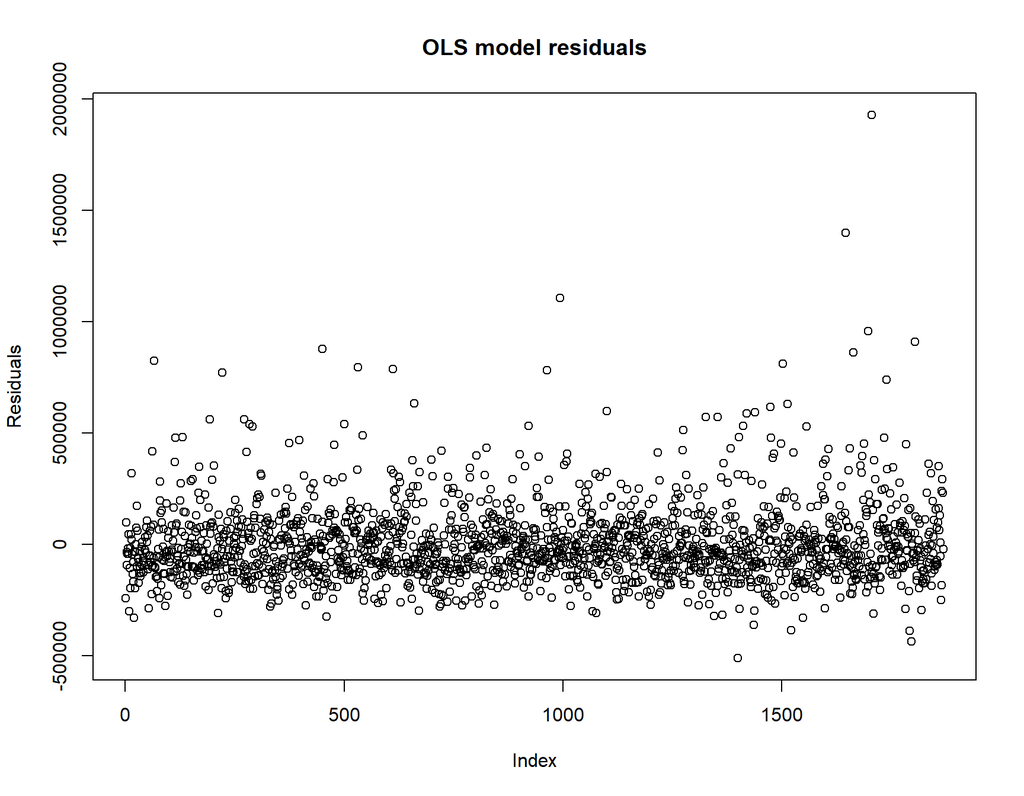

```r
 #indicates a spatial lag model will be the best fit
plot(mod22$residuals, main= "OLS model residuals", ylab="Residuals")
```

```r
par(mfrow=c(1,1))
```